# Implementos de acople en un tractor

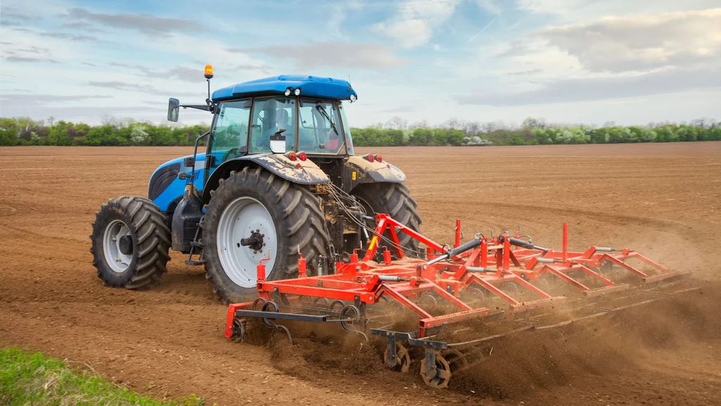

## Introducción

Los **implementos de acople** son herramientas o equipos que se conectan al **tractor agrícola** para realizar distintas labores dentro del proceso productivo del campo. Su función principal es **facilitar y optimizar el trabajo agrícola** en tareas como la preparación del suelo, la siembra, la fertilización y el control de plagas.

## Actividad 1

La TDF (toma de fuerza) del tractor transmite potencia mecánica en forma de giro a distintos implementos que la necesitan para accionar sus mecanismos. No todos los implementos la usan: algunos solo requieren tracción o elevación hidráulica pero otros dependen directamente del movimiento rotativo de la TDF.

Aquí puedes ver como la TDF tiene estrías que encajan en el eje cardánico del implemento:

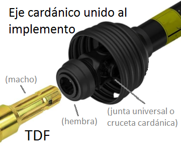

Responder brevemente:

**a)** Básicamente las TDF tienen 2 velocidades (rpm), poner cuales son esos valores y cuál es el más común (si es que hay una más común) y cuantas estrías tienen.

**b)** ¿Qué es el eje cardánico?

**c)** Dar ejemplos de implementos que necesitan la TDF

## Actividad 2

Describir brevemente cada uno de estos tipos de implementos: a) arado, b) rastras, c) cinceles y d) subsoladores

(En clase vamos a continuar viendo otros implementos)

## Actividad 3

(Hay que explicar oralmente esta actividad)

Hay otros implementos que se pueden montar en un tractor, como las sembradoras, las fertilizadoras, las fumigadoras, etc. Las sembradoras pueden ser para siembra convencional o directa.

**a)** Describir brevemente las diferencias entre siembra directa y convencional.

**b)** Dibujar esquemáticamente un tren de siembra convencional nombrando y explicando sus partes. Se trata de un tren de siembra que no trabaja a voleo sino que coloca las semillas en un surco. Puedes ver los primeros 8 minutos de este [video](https://www.youtube.com/watch?v=vuZoD1V-3G4) como fuente de información.

**c)** Idem b) pero para siembra directa. Puedes ver el mismo video como fuente de información.